# HomeWork 3

Ahmad Zohaib

Febuary 15, 2017

I. The goal of this problem is to simulate a binomial ran-dom variable. Consider a class with 40 students, and the probability that a student does not turn in a homework is 0.05 (a “success”). Assume all students are indepen-dent of all other students, and the probability does not change.

1. Use sample to simulate drawing 40 students who either do, or do not, turn in their homework, and then ﬁnd the total (out of 40) who did not turn in their homework. You should return one number, X = total # of students out of 40 who did not turn in their homework.

```
## [1] 2
```

2. Repeat (a) 1000000 times (you should have 1000000 values for “number of successes”,or X), plot a his-togram of your result (do not print out the 1000000 values!!).

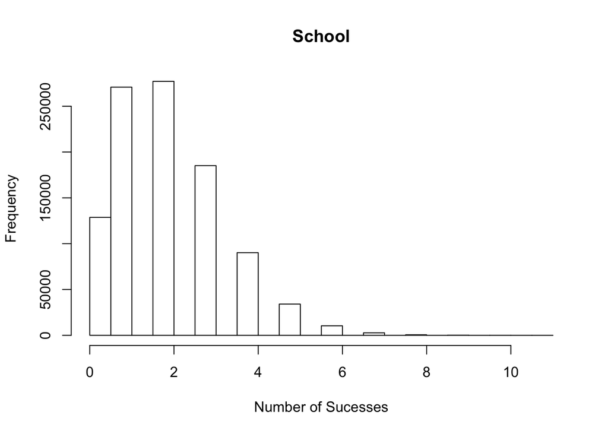

3. For this particular binomial distribution, is the dis-tribution symmetric? Explain.

Answer: No its is not symmertricla. There is no trend that shows symmerty. There is a trend in the histogram but it is not symmetric.

4. What appears to be the most frequently occurring value based on (b)? Then, ﬁnd the most frequently occurring value using R ( hint, the function table may be useful). Answer: The number thats occuring most frequently is 2.

```
## Sim
##      0      1      2      3      4      5      6      7      8      9
## 128722 270846 277162 185166  90195  34089  10398   2691    595    117
##     10     11
##     18      1
```

2. Continue with Problem I.
1. Find the average of the number of successes in 40 trials and the standard deviation based on your simulation from I(b).

```
## [1] 1.999122
```

```
## [1] 1.37859
```

2. Estimate the probability that all students turned in their homework based on your simulation from I(b).

```
## [1] 0.128722
```

3. Estimate the probability that at least two students did not turn in their homework based on your sim-ulation from I(b).

```
## [1] 0.600432
```

4. What is the median number of students who will forget their homework based on your simulation from I(b)?

```
## [1] 2
```

3. We will simulate a game that involves rolling a fair 8 sided die, twice, where the winnings of the game is twice the value of the ﬁrst die minus the value of the second die. For example, if you ﬁrst roll a 1 and next a 3, your loss is 2(1) - 3 = -1. Using 100000 simulations, estimate the following proba-bilities.
1. You win nothing (a win/loss of 0).